# Chapter 5 - Data Visualization for Bioinformatics

Sasha Ajay Malkani

2025-12-22

# Chapter 5: Data Visualization for Bioinformatics

Bioinformatics involves the analysis of vast amounts of diverse data, including genomic sequences, protein structures, metabolic pathways and gene expression profiles. Effective visualization techniques can simplify the interpretation of these data sets, revealing patterns, trends and relationships that are critical for biological discoveries and innovations. In this chapter, we will explore various data visualization techniques relevant to bioinformatics, the tools and libraries available for creating visualizations, and case studies demonstrating the application of these techniques in real-world scenarios.

## 1. Importance of Data Visualization in Bioinformatics

### 1. A. Understanding Multidimensional Data.

Biological data is often high-dimensional and complex. Genomic data, for instance, many involve thousands of genes with various expression levels across multiple conditions or time points. Visualization aids in reducing this complexity by providing a graphical representation that allows researchers to explore and identify significant trends and anomalies. Tools like Principal Components Analysis (PCA) plots and t-SNE (t-distributed Stochastic Neighbor Embedding) offer intuitive representations that help on dimensionality reductions, making it easier to visualize relationships among different data sets.

### 1. B. Communicating Results

The communication of results to stakeholders, including researchers, clinicians, and the public, is vital for advancing scientific knowledge and translational medicine. Well-designed visualizations can convey complex bioinformatics findings effectively, allowing for clearer interpretation and engagement.

Visualization can transform statistical outputs into more accessible formats, making it easier for non-experts to grasp essential discoveries.

### 1. C. Hypothesis Generation

Visual exploration of data can lead to new hypotheses and questions that might not arise through traditional analytical methods alone. For instance, cluster heat maps can visually demonstrate co-expression patterns of genes in different samples, suggesting potential regulatory relationships that merit further investigation.

## 2. Common Data Visualization Techniques in Bioinformatics

### 2. A. Heat maps

Heat maps are widely used in bioinformatics to represent data matrices, such as gene expression levels across different samples. They allow for the visualization of hierarchies and patterns through color gradients, enabling quick identification of clusters or outliers. Common libraries like Seaborn in Python or ggplot2 in R facilitate the creation of informative heat maps with ease.

### 2. B. Scatter Plots

Scatter plots are effective for visualizing correlations between two continuous variables. In genomics, scatter plots can illustrate the relationship between gene expression levels in different conditions, aiding in the identification of potential biomarkers or therapeutic targets. Additionally, bubble plots can enhance scatter plots by adding a third variable through the size and color of the points.

### 2. C. Box Plots

Box plots are useful for comparing distributions of gene expression across different categories, such as treatment groups or phenotypes. They succinctly represents measures of central tendency and variability, revealing insights into data distribution and identifying potential outliers.

### 2. D. Network Graphs

Biological systems are inherently interconnected, and visualizing these relationships is crucial for understanding complex interactions. Network graphs can depict protein-protein interactions, gene regulatory networks, and metabolic pathways, helping researchers visualize and explore the interconnectedness of biological entities.

### 2. E. Genomic Visualizations

Genomic data can be visualized through various methods, including genome browsers, which allow for the exploration of genomes at different scales. Tools such as IGV (Integrative Genomics Viewer) provide interactive interfaces for examining sequence alignments, variant calls and annotations in a user-friendly format.

## 3. Tools and libraries for Data Visualization.

A wide array of tools and libraries are available for generating visualizations in bioinformatics:

**Python Libraries**:

- **Matplotlib**: A foundational library for creating static, animated and interactive visualizations in Python.
- **Seaborn**: Built on Matplotlib, it provides a high-level interface for drawing attractive and informative statistical graphics.
- **Ploty**: Facilitates the creation of interactive plots and dashboards, making data explorations more engaging.

**R Packages**:

- **ggplot2**: A powerful and flexible visualization package based on the Grammar of Graphics, widely used in the bioinformatics community.
- **ComplexHeatmap**: Specifially designed for creating complex heatmaps and annotations.
- **Visualizations Platforms**:
- **Tableau**: A business intelligence tool that allows users to create interactive, shareable dashboards. Although not bioinformatics-specific, it can be leveraged for biological data visualization.
- **Cytoscape**: A platform for visualizing complex networks and integrating these with any type of attribute data, commonly used in systems biology.

## 4. Case Studies

### 4. A. Case Study 1: The Genomic Expression of Cancer

In a study analyzing the expression levels of thousands of genes in tumor versus normal tissues, researchers used heatmaps to display differential expression patterns. Clustering techniques revealed distinct groups of genes associated with specific cancer types, which were further investigated for potential diagnostic and therapeutic applications.

### 4. B. Case Study 2: Protein Interaction Networks

Researchers investigating the interactions of proteins related to Alzheimer’s disease used network graphs to visualize the complex interplay between various proteins. This visualization facilitated the identification of key regulatory proteins that may serve as targets for new therapeutic strategies.

## 5. Best practices for Effective Visualization

- **Clarity**: Ensure that visualizations clearly convey the intended message. Use appropriate scales, labels and legends to avoid misinterpretation.
- **Simplicity**: Avoid over-complicating visualizations. Focus on conveying the primary finding without unnecessary embellishments.
- **Interactivity**: Where possible, provide interactive visualizations that allow users to delve deeper into the data and explore different aspects.
- **Consistency**: Use consistent color schemes and styles across related visualizations that allow users to delve deeper into the data and explore different aspects.

By leveraging various visualization techniques and tools, researchers can uncover biological insights, communicate their findings effectively, and engage in hypothesis generation. As the field of bioinformatics continues to evolve, so too will the methods and technologies for data visualization, enabling deeper understanding of biology at every level.

## 6. Creating Effective Plots for Biological Data with ggplot2.

This chapter will guide you through the fundamentals of using ggplot2 for biological data, including how to prepare your data, create basic plots, customize visualizations, and incorporate best practices for data presentation.

### 6. A. Understanding ggplot2 Basics

Before we dive into creating plots, it’s crucial to understand how ggplot2 organizes and structures plotting. At its core, ggplot2 builds plots layer by layer, allowing for immense flexibility. The basic structure of a ggplot command follows this syntax:

ggplot(data, aes(x = …, y = …,)) + geom_(type)(parameters)

- **data**: The data frame containing your biological data
- **aes**: Aesthetic mappings that specify how data should be mapped to visual
- properties (like x and y coordinates, colors, sizes).
- **geom**: The geometric object that represents the data (e.g., points, lines, bars). To start using ggplot2, you must first install and load the package.

#### 6. A. I. Load Libraries

```r
library(devtools)
library(Biobase)
library(tidyverse)
```

```r
library(ggplot2)
```

### 6. B. Preparing Your Biological Data

Before Visualizing your data, preparation is key. Often, biological data sets can be messy or not structured in a way that’s immediately useful for plotting. The folowing steps are essential

#### 6. B. I. Data Cleaning

Ensure your data set does not contain NA values or erroneous entries. Use functions such as ‘na.omit()’ or ‘tidyr::drop_na()’. Check your data types and transform them as needed, using ‘dplyr::mutate()’ for conversions.

```r
# Load in data from a connection
con =url("http://bowtie-bio.sourceforge.net/recount/ExpressionSets/bottomly_eset.RData")
load(file=con)
close(con)
ls()
```

```
## [1] "bottomly.eset" "con"
```

```r
bot = bottomly.eset
bot
```

```
## ExpressionSet (storageMode: lockedEnvironment)
## assayData: 36536 features, 21 samples
##   element names: exprs
## protocolData: none
## phenoData
##   sampleNames: SRX033480 SRX033488 ... SRX033494 (21 total)
##   varLabels: sample.id num.tech.reps ... lane.number (5 total)
##   varMetadata: labelDescription
## featureData
##   featureNames: ENSMUSG00000000001 ENSMUSG00000000003 ...
##     ENSMUSG00000090268 (36536 total)
##   fvarLabels: gene
##   fvarMetadata: labelDescription
## experimentData: use 'experimentData(object)'
## Annotation:
```

```r
pdata_bot=pData(bot)
head(pdata_bot)
```

```
##           sample.id num.tech.reps   strain experiment.number lane.number
## SRX033480 SRX033480             1 C57BL/6J                 6           1
## SRX033488 SRX033488             1 C57BL/6J                 7           1
## SRX033481 SRX033481             1 C57BL/6J                 6           2
## SRX033489 SRX033489             1 C57BL/6J                 7           2
## SRX033482 SRX033482             1 C57BL/6J                 6           3
## SRX033490 SRX033490             1 C57BL/6J                 7           3
```

```r
fdata_bot = featureData(bot)
head(fdata_bot)
```

```
## An object of class 'AnnotatedDataFrame'
##   featureNames: ENSMUSG00000000001 ENSMUSG00000000003 ...
##     ENSMUSG00000000049 (6 total)
##   varLabels: gene
##   varMetadata: labelDescription
```

```r
edata = exprs(bot)
head(edata, n=1)
```

```
##                    SRX033480 SRX033488 SRX033481 SRX033489 SRX033482 SRX033490
## ENSMUSG00000000001       369       744       287       769       348       803
##                    SRX033483 SRX033476 SRX033478 SRX033479 SRX033472 SRX033473
## ENSMUSG00000000001       433       469       585       321       301       461
##                    SRX033474 SRX033475 SRX033491 SRX033484 SRX033492 SRX033485
## ENSMUSG00000000001       309       374       781       555       820       294
##                    SRX033493 SRX033486 SRX033494
## ENSMUSG00000000001       758       419       857
```

```r
# Check genomic data for NAs
is.na(edata)[1,]
```

```
## SRX033480 SRX033488 SRX033481 SRX033489 SRX033482 SRX033490 SRX033483 SRX033476
##     FALSE     FALSE     FALSE     FALSE     FALSE     FALSE     FALSE     FALSE
## SRX033478 SRX033479 SRX033472 SRX033473 SRX033474 SRX033475 SRX033491 SRX033484
##     FALSE     FALSE     FALSE     FALSE     FALSE     FALSE     FALSE     FALSE
## SRX033492 SRX033485 SRX033493 SRX033486 SRX033494
##     FALSE     FALSE     FALSE     FALSE     FALSE
```

```r
# Change expression set (matrix) to a data frame
edata1 = as.data.frame(edata)
edata2 = as_tibble(edata)
edata3 = data.frame(edata)

# Log transform edata
log_edata = log2(edata1 +1)
head(log_edata)
```

```
##                    SRX033480 SRX033488 SRX033481 SRX033489 SRX033482 SRX033490
## ENSMUSG00000000001  8.531381  9.541097  8.169925  9.588715  8.447083  9.651052
## ENSMUSG00000000003  0.000000  0.000000  0.000000  0.000000  0.000000  0.000000
## ENSMUSG00000000028  0.000000  1.000000  0.000000  1.000000  1.000000  1.000000
## ENSMUSG00000000031  0.000000  0.000000  0.000000  0.000000  0.000000  0.000000
## ENSMUSG00000000037  0.000000  1.000000  1.000000  2.584963  0.000000  2.321928
## ENSMUSG00000000049  0.000000  1.000000  0.000000  1.000000  0.000000  0.000000
##                    SRX033483 SRX033476 SRX033478 SRX033479 SRX033472 SRX033473
## ENSMUSG00000000001  8.761551  8.876517  9.194757  8.330917  8.238405  8.851749
## ENSMUSG00000000003  0.000000  0.000000  0.000000  0.000000  0.000000  0.000000
## ENSMUSG00000000028  0.000000  3.000000  2.807355  1.000000  1.000000  1.000000
## ENSMUSG00000000031  0.000000  0.000000  0.000000  0.000000  0.000000  0.000000
## ENSMUSG00000000037  0.000000  0.000000  0.000000  0.000000  2.321928  1.000000
## ENSMUSG00000000049  0.000000  0.000000  0.000000  0.000000  0.000000  0.000000
##                    SRX033474 SRX033475 SRX033491 SRX033484 SRX033492 SRX033485
## ENSMUSG00000000001  8.276124  8.550747  9.611025  9.118941  9.681238  8.204571
## ENSMUSG00000000003  0.000000  0.000000  0.000000  0.000000  0.000000  0.000000
## ENSMUSG00000000028  1.000000  1.000000  1.000000  1.584963  1.000000  1.000000
## ENSMUSG00000000031  0.000000  0.000000  0.000000  0.000000  0.000000  0.000000
## ENSMUSG00000000037  1.000000  0.000000  1.000000  1.584963  1.000000  1.000000
## ENSMUSG00000000049  0.000000  0.000000  0.000000  0.000000  0.000000  0.000000
##                    SRX033493 SRX033486 SRX033494
## ENSMUSG00000000001  9.567956  8.714246  9.744834
## ENSMUSG00000000003  0.000000  0.000000  0.000000
## ENSMUSG00000000028  2.321928  1.000000  2.584963
## ENSMUSG00000000031  0.000000  0.000000  0.000000
## ENSMUSG00000000037  1.000000  1.000000  1.584963
## ENSMUSG00000000049  0.000000  0.000000  0.000000
```

#### 6. B. II. Data transformation

Sometimes, you may need to transform your data for analysis. This might involve calculating means, variances or creating new variables. The ‘dplyr’ package is excellent for data manipulation:

```r
# Load "dplyr" library
library(dplyr)

# Data Summarization

# Group the 21 samples into the two different strains
c57BL_6J = group_by(log_edata[,1:10])
DBA_2J = group_by(log_edata[,11:21])
genes = row.names(log_edata)

# Split each of the samples within the two strains into separate lists and concatenate them together
sample_1 = c(c57BL_6J[,1], c57BL_6J[,2], c57BL_6J[,3], c57BL_6J[,4], c57BL_6J[,5],
             c57BL_6J[,6], c57BL_6J[,7], c57BL_6J[,8], c57BL_6J[,9], c57BL_6J[,10],
             DBA_2J[,1], DBA_2J[,2], DBA_2J[,3], DBA_2J[,4], DBA_2J[,5], DBA_2J[,6],
             DBA_2J[,7], DBA_2J[,8], DBA_2J[,9], DBA_2J[,10], DBA_2J[,11])

# Un-list the large list with 21 elements
sample_1 = unlist(sample_1, use.names=FALSE)

# Create an atomic vector
sample_1 = as.vector(sample_1)

# Create a Sample Data Frame with the two strains as separate categories within the Group variable
gene_data <- data.frame(
  Group = c(rep("C57BL_6J", each = 365360), rep("DBA_2J", each = 401896)),
  genes = rep(genes, times = 21),
  Expression = sample_1)

head(gene_data)
```

```
##      Group              genes Expression
## 1 C57BL_6J ENSMUSG00000000001   8.531381
## 2 C57BL_6J ENSMUSG00000000003   0.000000
## 3 C57BL_6J ENSMUSG00000000028   0.000000
## 4 C57BL_6J ENSMUSG00000000031   0.000000
## 5 C57BL_6J ENSMUSG00000000037   0.000000
## 6 C57BL_6J ENSMUSG00000000049   0.000000
```

```r
tail(gene_data)
```

```
##         Group              genes Expression
## 767251 DBA_2J ENSMUSG00000090263   0.000000
## 767252 DBA_2J ENSMUSG00000090264   2.807355
## 767253 DBA_2J ENSMUSG00000090265   0.000000
## 767254 DBA_2J ENSMUSG00000090266   0.000000
## 767255 DBA_2J ENSMUSG00000090267   3.807355
## 767256 DBA_2J ENSMUSG00000090268   0.000000
```

```r
# Calculate the mean gene expression by the two different strains
mean_expression_by_group <- gene_data %>%
  group_by(Group) %>%
  summarize(
    Mean_Expression = mean(Expression, na.rm = TRUE), # Calculate mean, ignoring NAs
    Num_Samples = n() # Optional: count samples in each group
  )

print(mean_expression_by_group)
```

```
## # A tibble: 2 × 3
##   Group    Mean_Expression Num_Samples
##   <chr>              <dbl>       <int>
## 1 C57BL_6J            1.80      365360
## 2 DBA_2J              1.85      401896
```

### 6. C. Basic Plots with ggplot2

With your data prepared, you can start creating plots. This section covers the creation of some common plot types suitable for biological data.

#### 6. C. I. Scatter Plots

Scatter plots are used to examine relationships between two continuous variables For example, you could plot gene expression between strain c57BL_6J and DBA_2J

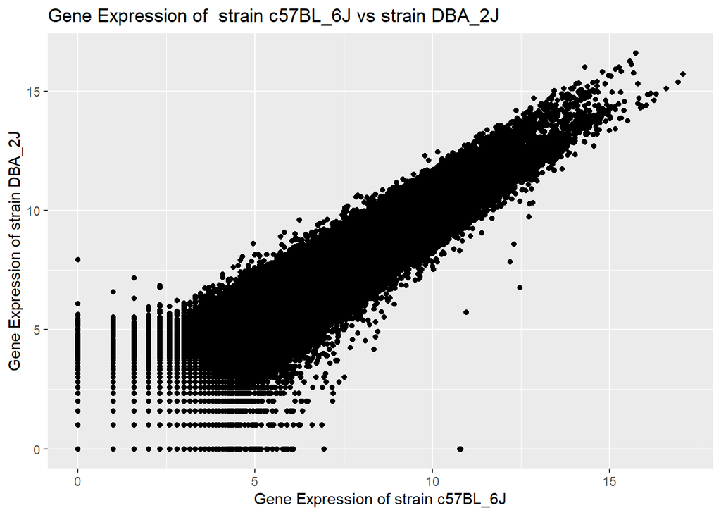

```r
# Data Visualization
library(ggplot2)

# NB - had to truncate the gene expression levels for the DBA_2J strain because it had one additional sample vs c57BL_6J
ggplot() + geom_point(aes(x = gene_data$Expression[1:365360], y = gene_data$Expression[365361:730720])) +
  labs(title = "Gene Expression of  strain c57BL_6J vs strain DBA_2J",
       x = "Gene Expression of strain c57BL_6J", y = "Gene Expression of strain DBA_2J")
```

#### 6. C. II. Bar plots

Bar plots are ideal for comparing categorical data. For instance, comparing average weights of different species:

```r
species_wt <- read.csv("Species_Weight.csv", header = TRUE, stringsAsFactors = FALSE)
species_wt
```

```
##          Species Weight.kg.
## 1  Bush Elephant       5443
## 2     Polar Bear        400
## 3          Human         75
## 4   Domestic Dog         40
## 5  Bush Elephant       5000
## 6     Polar Bear        300
## 7          Human        100
## 8   Domestic Dog         80
## 9  Bush Elephant       4700
## 10    Polar Bear        800
## 11         Human         60
## 12  Domestic Dog        110
```

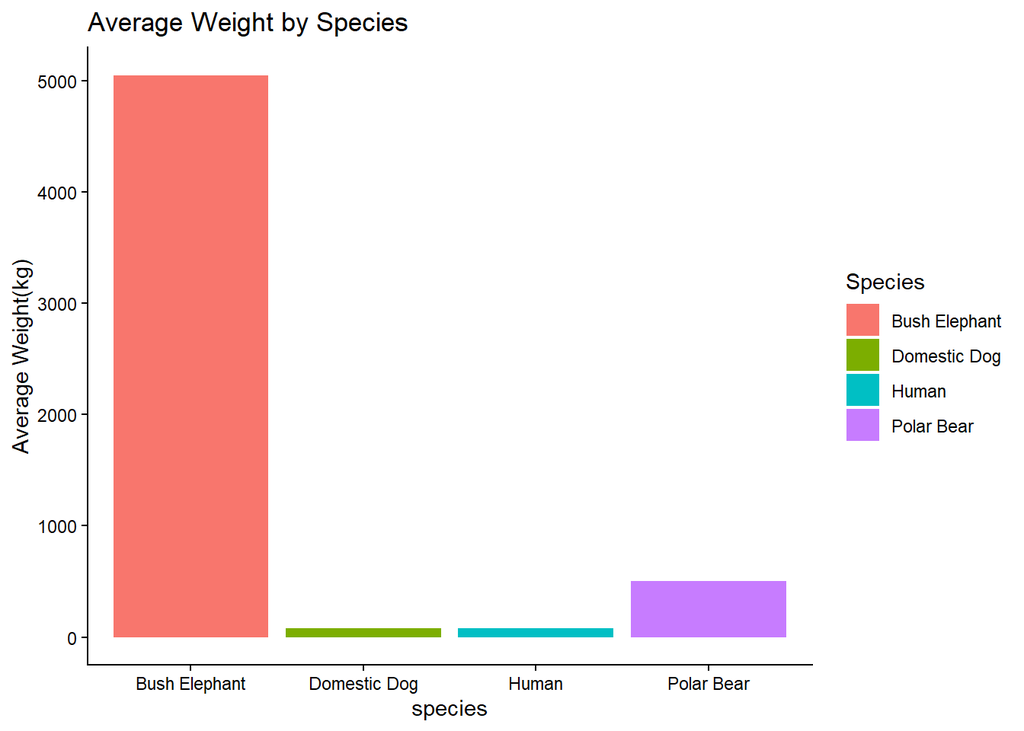

```r
ggplot(species_wt, aes(x = Species, y = Weight.kg., fill = Species)) +
  geom_bar(stat = "summary", fun = "mean") +
  labs(title = "Average Weight by Species", x = "species",
       y = "Average Weight(kg)") + theme_classic()
```

#### 6. C. III. Box plots

Boxplots are useful to visualize the distribution of a continuous variable across different categories. They can effectively display variance and outliers:

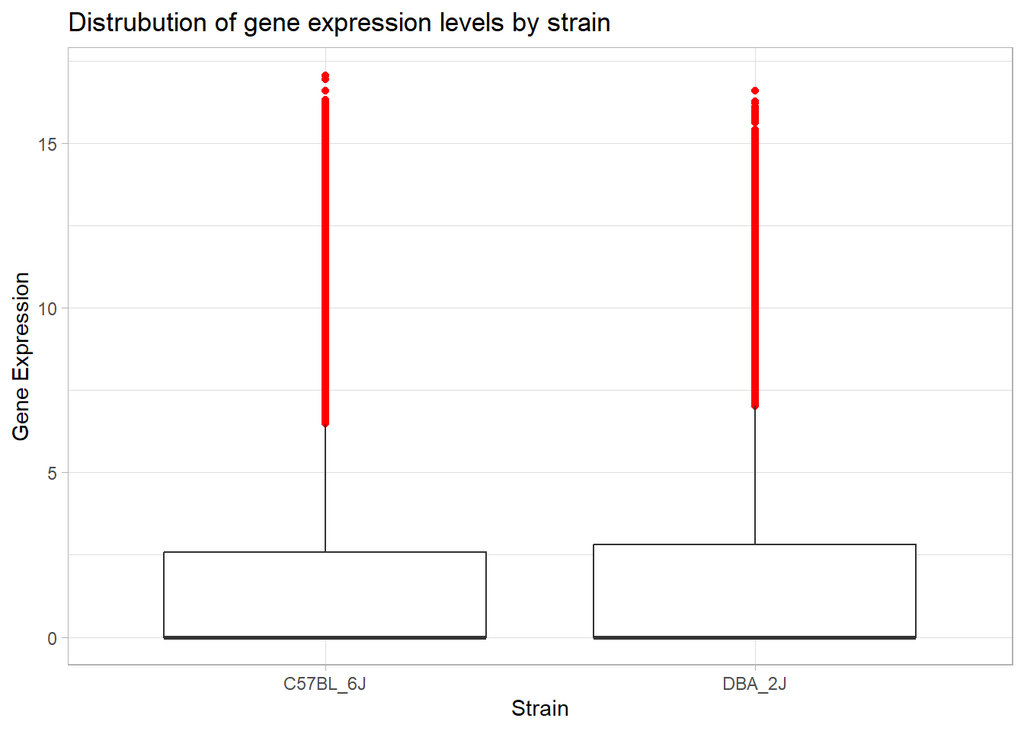

```r
ggplot(gene_data, aes(x = Group, y = Expression)) + geom_boxplot(outlier.colour = "red") +
  labs(title = "Distrubution of gene expression levels by strain", x = "Strain",
       y = "Gene Expression") + theme_light()
```

### 6. D. Customizing Your Plots

Customizing your plots can enhance their clarity and aesthetic appeal. Here are some common customizations:

#### 6. D. I. Themes

ggplots2 comes with several built-in themes that can modify the overall appearance of your plots. Use “theme_*()” functions to easily adjust your plot’s aesthetics:

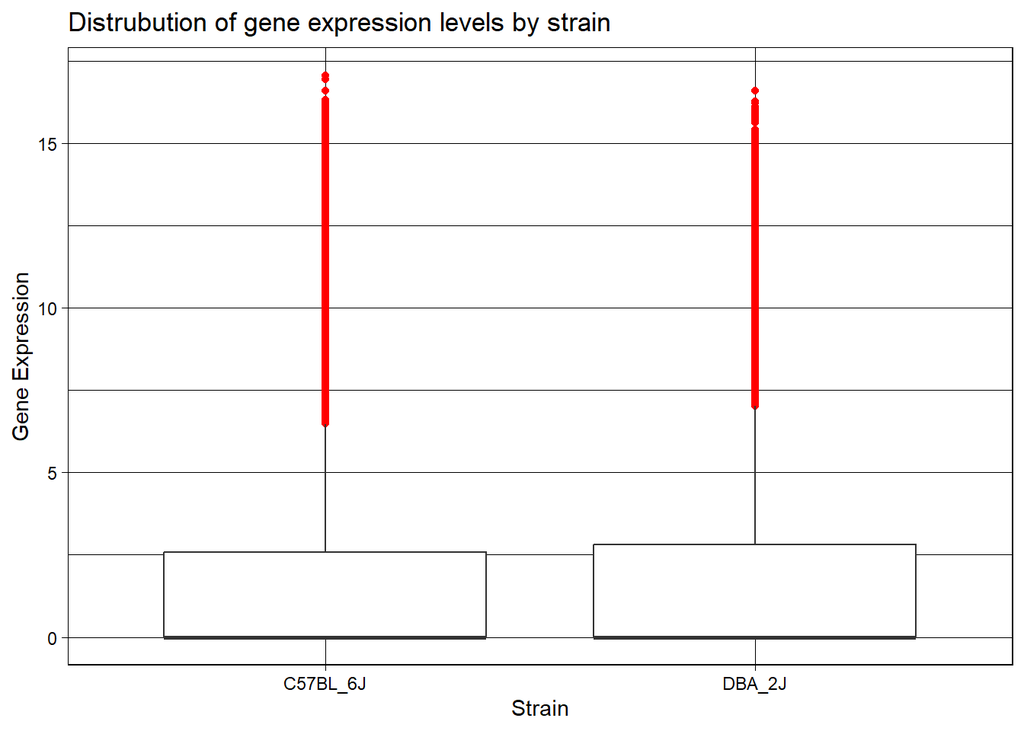

```r
ggplot(gene_data, aes(x = Group, y = Expression)) + geom_boxplot(outlier.colour = "red") +
  labs(title = "Distrubution of gene expression levels by strain", x = "Strain",
       y = "Gene Expression") + theme_linedraw()
```

#### 6. D. II. Color and Fill

Using distinct colors helps differentiate categories. You can specific colors directly in the “aes()” function:

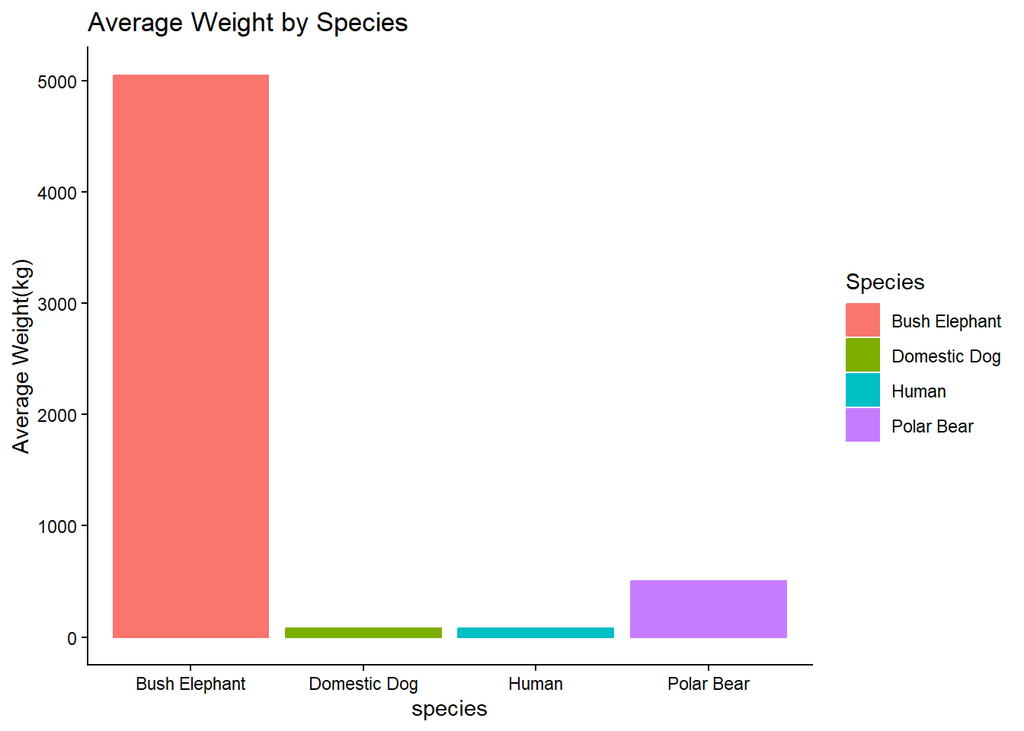

```r
ggplot(species_wt, aes(x = Species, y = Weight.kg., fill = Species, colour = Species)) +
  geom_bar(stat = "summary", fun = "mean") +
  labs(title = "Average Weight by Species", x = "species",
       y = "Average Weight(kg)") + theme_classic()
```

#### 6. D. III. Labels and titles

Always include informative titles and axis labels to guide the audience. Use the “labs()” function or “ggtitle()” for titles.

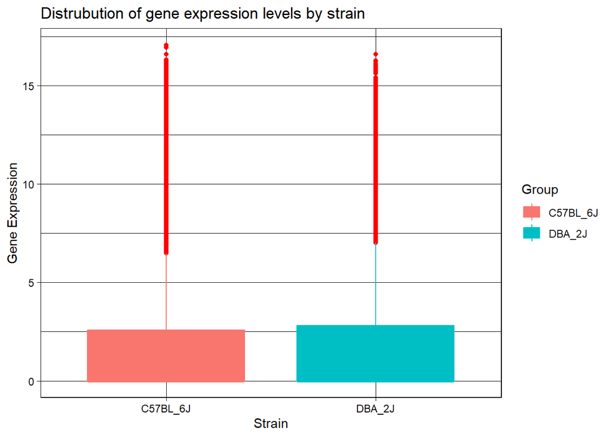

```r
ggplot(gene_data, aes(x = Group, y = Expression, fill = Group, color = Group)) + geom_boxplot(outlier.colour = "red") +
  labs(title = "Distrubution of gene expression levels by strain", x = "Strain",
       y = "Gene Expression") + theme_linedraw()
```

## 7. Best Practices in Scientific Visualization

When visualizating biological data, adherence to best practices enhances data interpretation:

- **Keep it Simple**: Avoid clutter and focus on the data.
- **Use Appropriate Scales**: Use logarithmic scales if data spans multiple orders of magnitude.
- **Incorporate Legends Wisely**: Ensure the legend is informative and doesn’t # obscure data.
- **Test Different Presentations**: Sometimes, a different plot type might better convey your message.

By preparing data appropriately, mastering basic plots, customizing aesthetics, and following best practices, you can create informative and visually appealing graphics that enhance your research storytelling. ggplot2 is a versatile tool that, once mastered, can significantly improve the presentation of your biological data analyses. Happy plotting!

## 8. Visualizing Genomic Data with Gviz and Other Tools

One of the key challenges in genomics is the effective visualization of complex genomic data, which is essential for interpretation and communication of research findings. In this chapter, we will explore the powerful tools available in R, focusing on the Gviz package, as well as other visualization techniques that complement Gviz

### 8. A. Understanding Genomic Data.

Genomic data can comprise a wide variety of information, including gene annotations, expression levels, variant data can help researchers identify patterns, test hypotheses, and communicate their findings more clearly. For instance, visual representations of genomic data can highlight gene structures, expressional differences between conditions, and the localization of genomic features.

### 8. B. Getting Started with Gviz

#### 8. B. I. Installation and Setup

To begin using Gviz, you need to have R and Bioconductor installed. If you haven’t already set it up, you can find installation instructions on the Bioconductor website. After setting up Bioconductor, Gviz can be installed with the following commands:

```r
# if(!requireNamespace("BiocManager", quietly = TRUE))
#    installed.packages("BiocManager")

# BiocManager::install()

# BiocManager::install(c("SparseArray", 'GenomicRanges', 'S4Arrays'),
# type = "source", force = TRUE)

# BiocManager::install("Gviz")
```

#### 8. B. II. Basic Concepts of Gviz

Gviz is a flexible R package designed specifically for visualizing genomic data. It allows users to create a variety of plots, including gene models, ideograms, and coverage plots, while integrating different layers of genomic information.

#### 8. B. III. Creating Your First Plot

Let’s walk through the steps to create a simple genomic plot using Gviz. The following example shows how to visualize gene annotation data.

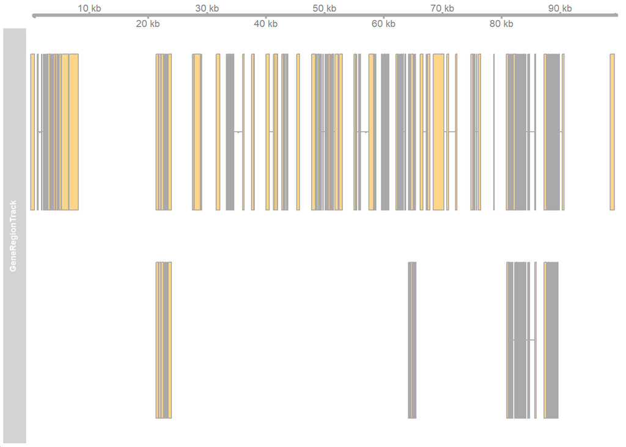

```r
# Load Library
library(Gviz)
# Create a GeneRegionTrack
geneTrack <- GeneRegionTrack("D:/Ajay Files/R Programming for Bioinformatics/Chapter 5/athal_genes.gtf")

# Create a Genome Axis Track
genomeTrack <- GenomeAxisTrack()

# Create the plot
plotTracks(list(genomeTrack, geneTrack), from = 1, to = 100000)
```

#### 8. B. IV. Customizing Your Plots

Gviz offers extensive customization options for enhancing the aesthetics of your plots. This includes changing colors, labels, and track heights. For example, the following code snippet shows how to customize the colors and add a title.

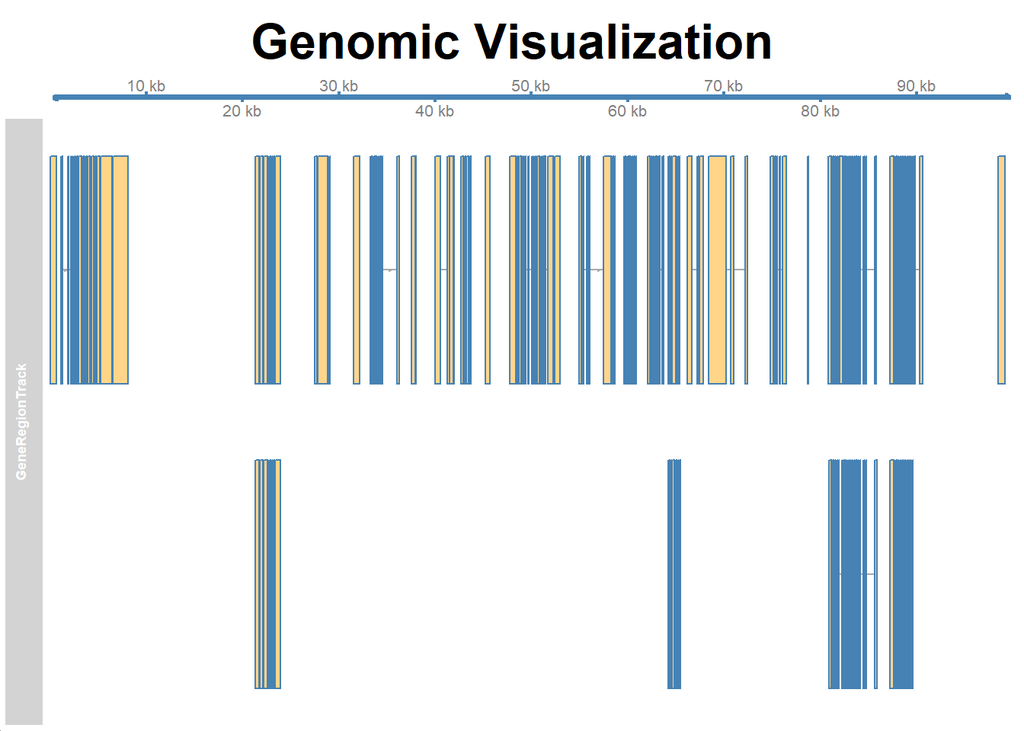

```r
plotTracks(list(genomeTrack, geneTrack), from = 1, to = 100000,
           main = "Genomic Visualization", background.fill = "lightgrey",
           col = "steelblue")
```

## 9. Integrating Other Visualization Tools

While Gviz provides a comphrehensive approach to genomic data visualization, other R packages also complement Gviz well. Here are a few notable examples:

### 9. A. ggplot

“ggplot” is a versatile plotting system that can be used for a variety of data visualization tasks, including genomic data. Combining Gviz with ggplot2 can enhance the interactivity and customize plots beyond the capabilities of Gviz alone. For example, you can extract data from Gviz, manipulate it using “dplyr”, and visualize it using “ggplot2”

### 9. B. Complex Heatmap

“ComplexHeatmap” is another powerful R package for visualizing complex data matrices, specifically tailored for high-dimensional genomic data. It allows users to create annotated heatmaps that can include various track annotations, providing a great way to visualize gene expression data alongside genomic features.

### 9. C. Plotly

“plotly” is focused on creating interactive plots and can be effectively used with Gviz outputs. By converting static Gviz plots into interactive web visuals, researchers can explore their data in more detail.

## 10. Case Studies

### 10. A. Case Study 1: Differential Expression Analysis

In a typical analysis pipeline, one might start with statistical tests to identify differentially expressed genes (DEG’s). After obtaining a set of DEG’s, Gviz can be used to visualize expression levels across different conditions. The combination of Gviz with heatmaps and volcano plots provides a comprehensive understanding of the data.

### 10. B. Case Study 2: Variant Visualization

When working with genomic variants, Gviz can visualize SNPs or structural variants alongside gene annotations and other genomic features. By overlaying variant data on gene tracks, researchers can identify potential functional impacts of variants in research questions related to disease.

Visualizing genomic data is a crucial component of genomics research. With the Gviz package and other visualization tools in R, researchers can create informative and compelling visual representations of complex genomic information. By integrating multiple visualization packages, you can take your analyses to the next level, leveraging the strengths of each library to produce comprehensive, interactive and insightful genomic visualizations

```r
Sys.Date()
```

```
## [1] "2026-01-18"
```